# Credit Card Users Churn Prediction

```python
for i, data in df.iterrows():
    if data.contacts < 1:
        df.at[i, 'contacts'] = 1
    elif data.contacts > 4:
        df.at[i, 'contacts'] = 4
```

Credit Limit

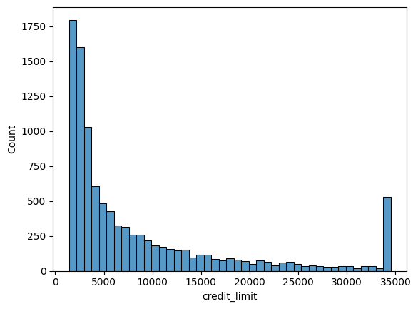

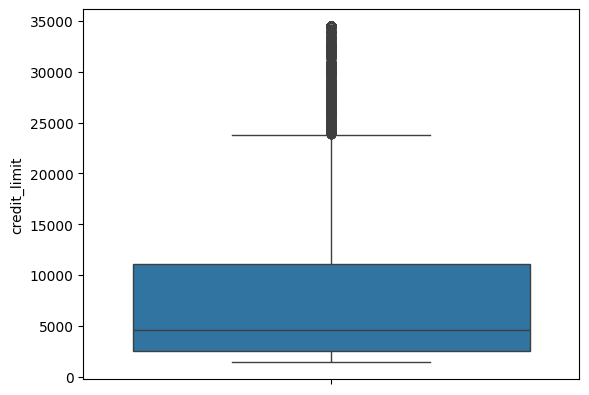

```
max:  34516.0
min:  1438.3
Mean:  8631.953698034955

IQR STRATEGY ------------
Q1:  2555.0
Q2 (median):  4549.0
Q3:  11067.5
Left whisker:  -10213.75
Right whisker:  23836.25

QUANTILE STRATEGY ------------
95th percentile:  34516.0
5th percentile:  1438.51

(IQR Strategy) NUMBER OF OUTLIERS DETECTED IN THE credit_limit COLUMN: 984
(Quantile Strategy) NUMBER OF OUTLIERS DETECTED IN credit_limit COLUMN: 507
```

```python
outlier('credit_limit')
```

```python
df[(df.credit_limit < 1438.52) | (df.credit_limit > 34516.0)].credit_limit.describe()
```

```
count    5.070000e+02
mean     1.438300e+03
std      7.283144e-12
min      1.438300e+03
25%      1.438300e+03
50%      1.438300e+03
75%      1.438300e+03
max      1.438300e+03
Name: credit_limit, dtype: float64
```

```python
# Replacing outlier values with the 5th percentile value
for i, data in df.iterrows():
    if data['credit_limit'] < 1438.51:
        df.at[i, 'credit_limit'] = 1438.51
```

Revolving Balance: total revolving balance on the credit card¶ In credit card terms, a revolving balance is the portion of credit card spending that goes unpaid at the end of a billing cycle. The amount can vary, going up or down depending on the amount borrowed and the amount repaid. If you revolve a balance — that is, not pay it off at the end of the month — the lender will charge you for the privilege of borrowing their money. The amount of the charge for revolving a balance will depend on the size of the balance and the interest rate of the card. When the balance is paid off, the customer is no longer revolving the debt.

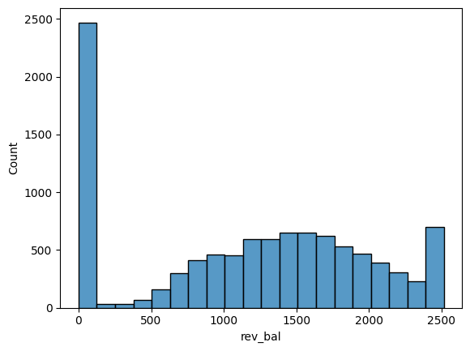

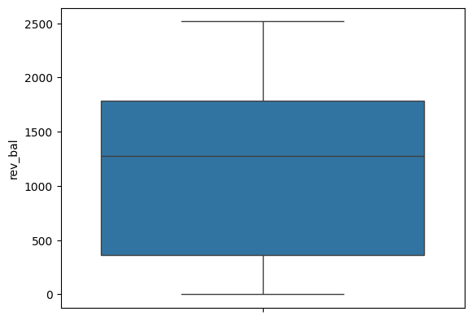

```
max:  2517
min:  0
Mean:  1162.8140614199665

IQR STRATEGY ------------
Q1:  359.0
Q2 (median):  1276.0
Q3:  1784.0
Left whisker:  -1778.5
Right whisker:  3921.5

QUANTILE STRATEGY ------------
95th percentile:  2517.0
5th percentile:  0.0

(IQR Strategy) NUMBER OF OUTLIERS DETECTED IN THE rev_bal COLUMN: 0
(Quantile Strategy) NUMBER OF OUTLIERS DETECTED IN rev_bal COLUMN: 0
```

```python
outlier('rev_bal') # no outliers
```

Buy: open to buy credit line in the last 12 months: credit_limit - rev_bal

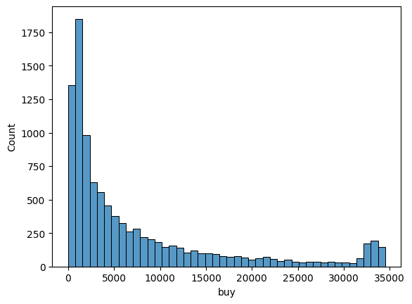

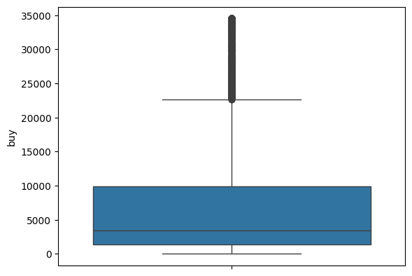

```
max:  34516.0
min:  3.0
Mean:  7469.139636614989

IQR STRATEGY ------------
Q1:  1324.5
Q2 (median):  3474.0
Q3:  9859.0
Left whisker:  -11477.25
Right whisker:  22660.75

QUANTILE STRATEGY ------------
95th percentile:  32183.399999999998
5th percentile:  480.3

(IQR Strategy) NUMBER OF OUTLIERS DETECTED IN THE buy COLUMN: 963
(Quantile Strategy) NUMBER OF OUTLIERS DETECTED IN buy COLUMN: 1014
```

```python
outlier('buy')
```

```python
df[df.buy > 22660.75].buy.describe() # outliers on the right, that is, points greater than the right whisker value
```

```
count      963.000000
mean     30531.662513
std       3650.608893
min      22664.000000
25%      27709.000000
50%      32329.000000
75%      33256.500000
max      34516.000000
Name: buy, dtype: float64
```

```python
df[df.buy > 27709].buy.describe()
```

```
count      722.000000
mean     32398.023546
std       1777.605202
min      27710.000000
25%      31999.000000
50%      32853.000000
75%      33511.250000
max      34516.000000
Name: buy, dtype: float64
```

amt_change: Change in Transaction Amount (Q4 over Q1)

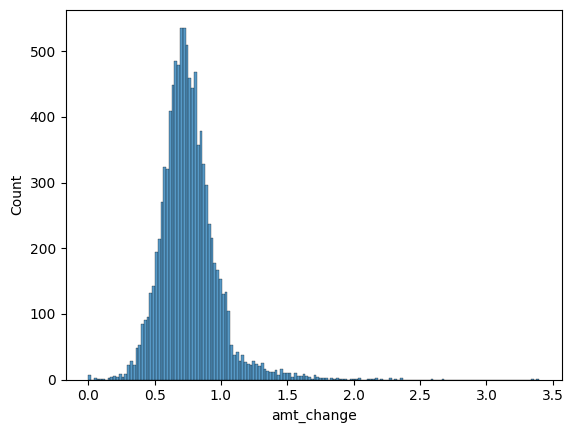

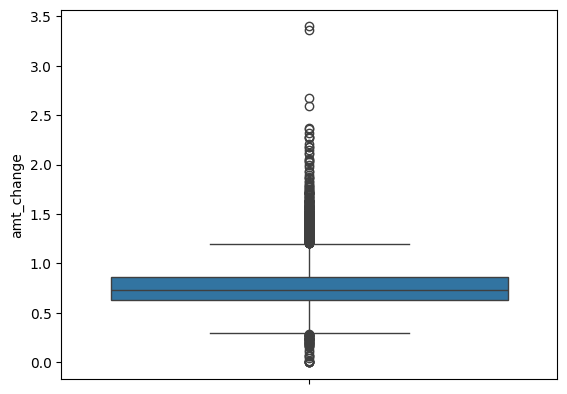

```
max:  3.397
min:  0.0
Mean:  0.7599406536980349

IQR STRATEGY ------------
Q1:  0.631
Q2 (median):  0.736
Q3:  0.859
Left whisker:  0.28900000000000003
Right whisker:  1.201

QUANTILE STRATEGY ------------
95th percentile:  1.103
5th percentile:  0.463

(IQR Strategy) NUMBER OF OUTLIERS DETECTED IN THE amt_change COLUMN: 396
(Quantile Strategy) NUMBER OF OUTLIERS DETECTED IN amt_change COLUMN: 1006
```

```python
outlier('amt_change')
```

```python
df[df.amt_change > 1.2].amt_change.describe()
```

```
count    350.000000
mean       1.464049
std        0.290201
min        1.201000
25%        1.276000
50%        1.373000
75%        1.553750
max        3.397000
Name: amt_change, dtype: float64
```

```python
df[df.amt_change > 1.55].amt_change.describe()
```

```
count    89.000000
mean      1.835135
std       0.346375
min       1.553000
25%       1.621000
50%       1.707000
75%       1.932000
max       3.397000
Name: amt_change, dtype: float64
```

```python
# dropping amt_change values beyond 1.55
df.drop(index = df[df.amt_change > 1.55].index, inplace = True)
df.shape
```

```
(10038, 23)
```

```python
df[df.amt_change < 0.289].amt_change.describe()
# we note that these outlier values are not greatly different than the lower whisker, hence we equate them to the loer whisker
```

```
count    47.000000
mean      0.173149
std       0.092935
min       0.000000
25%       0.110500
50%       0.202000
75%       0.241500
max       0.280000
Name: amt_change, dtype: float64
```

```python
# equating amt_change values beyond 1.2 (right whisker) and less than 1.55 -- 261 values
for i, data in df.iterrows():
    if data['amt_change'] > 1.2:
        df.at[i, 'amt_change'] = 1.2
    if data['amt_change'] < 0.289:
        df.at[i, 'amt_change'] = 0.289
```

Trans_amt: total amount in transactions in the last 12 months

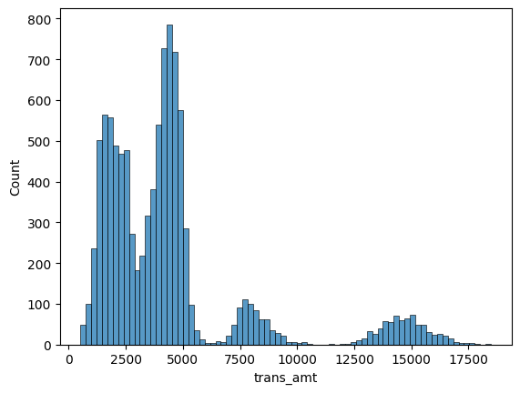

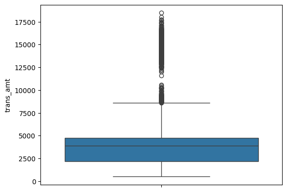

```
max:  18484
min:  510
Mean:  4425.29348475792

IQR STRATEGY ------------
Q1:  2170.0
Q2 (median):  3914.5
Q3:  4750.0
Left whisker:  -1700.0
Right whisker:  8620.0

QUANTILE STRATEGY ------------
95th percentile:  14220.0
5th percentile:  1283.0

(IQR Strategy) NUMBER OF OUTLIERS DETECTED IN THE trans_amt COLUMN: 895
(Quantile Strategy) NUMBER OF OUTLIERS DETECTED IN trans_amt COLUMN: 1001
```

```python
outlier('trans_amt')
```

```python
df[df.trans_amt > 8619.25].trans_amt.describe()
```

```
count      896.000000
mean     13770.194196
std       2302.445950
min       8620.000000
25%      13309.750000
50%      14379.500000
75%      15196.000000
max      18484.000000
Name: trans_amt, dtype: float64
```

```python
df[df.trans_amt > 15000].trans_amt.describe() # to be dropped
```

```
count      285.000000
mean     15767.922807
std        645.891175
min      15004.000000
25%      15226.000000
50%      15581.000000
75%      16202.000000
max      18484.000000
Name: trans_amt, dtype: float64
```

```python
df.drop(index = df[df.trans_amt > 15000].index, inplace = True)
```

```python
# equating amt_change values beyond 1.2 (right whisker) and less than 1.55 -- 261 values
for i, data in df.iterrows():
    if data['trans_amt'] > 8620:
        df.at[i, 'trans_amt'] = 8620
```

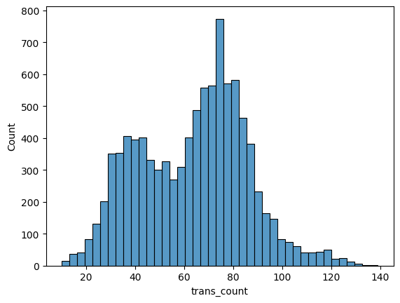

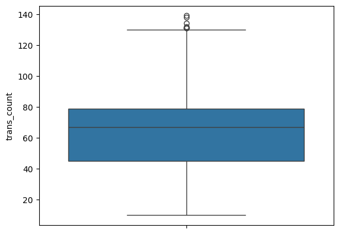

```
max:  139
min:  10
Mean:  63.69855429098739

IQR STRATEGY ------------
Q1:  45.0
Q2 (median):  67.0
Q3:  79.0
Left whisker:  -6.0
Right whisker:  130.0

QUANTILE STRATEGY ------------
95th percentile:  98.0
5th percentile:  28.0

(IQR Strategy) NUMBER OF OUTLIERS DETECTED IN THE trans_count COLUMN: 8
(Quantile Strategy) NUMBER OF OUTLIERS DETECTED IN trans_count COLUMN: 907
```

```python
outlier('trans_count')
```

```python
for i, data in df.iterrows():
    if data['trans_count'] > 135:
        df.at[i, 'trans_count'] = 135
```

trans_count_change: change in transaction count Q4 over Q1

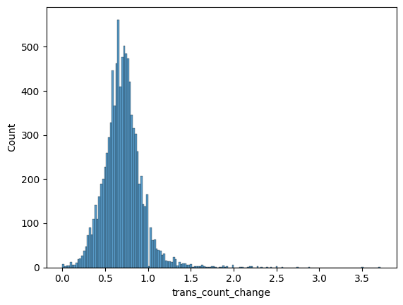

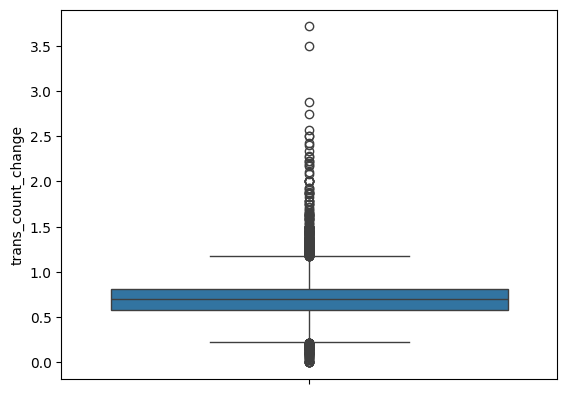

```
max:  3.714
min:  0.0
Mean:  0.706407054239721

IQR STRATEGY ------------
Q1:  0.577
Q2 (median):  0.698
Q3:  0.816
Left whisker:  0.21849999999999997
Right whisker:  1.1744999999999999

QUANTILE STRATEGY ------------
95th percentile:  1.056
5th percentile:  0.364

(IQR Strategy) NUMBER OF OUTLIERS DETECTED IN THE trans_count_change COLUMN: 345
(Quantile Strategy) NUMBER OF OUTLIERS DETECTED IN trans_count_change COLUMN: 953
```

```python
outlier('trans_count_change')
```

```python
df[df.trans_count_change > 1.5].trans_count_change.describe()
```

```
count    62.000000
mean      1.974097
std       0.441560
min       1.522000
25%       1.638750
50%       1.875000
75%       2.178250
max       3.714000
Name: trans_count_change, dtype: float64
```

```python
df[df.trans_count_change < 0.23].trans_count_change.describe()
```

```
count    96.000000
mean      0.147750
std       0.067064
min       0.000000
25%       0.106500
50%       0.169000
75%       0.201500
max       0.227000
Name: trans_count_change, dtype: float64
```

```python
df.drop(index = df[df.trans_count_change > 1.5].index, inplace = True)
```

```python
for i, data in df.iterrows():
    if data['trans_count_change'] > 1.16:
        df.at[i, 'trans_count_change'] = 1.16
    if data['trans_count_change'] < 0.23:
        df.at[i, 'trans_count_change'] = 0.23
```

util: average card utilization ratio = rev_bal / credit_limit

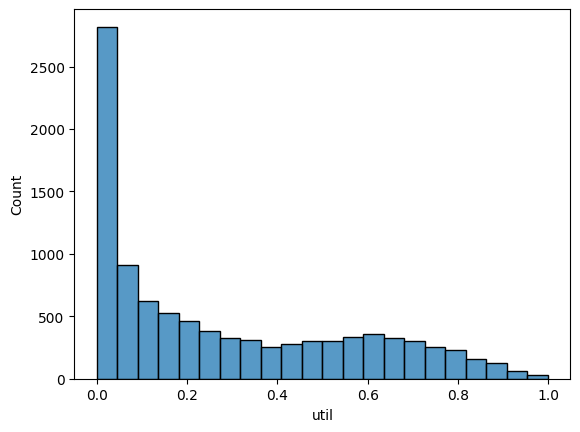

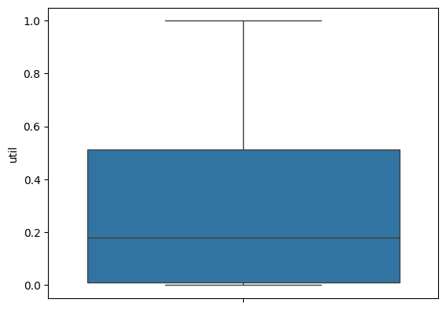

```
max:  0.999
min:  0.0
Mean:  0.27703477453307196

IQR STRATEGY ------------
Q1:  0.010499999999999999
Q2 (median):  0.178
Q3:  0.511
Left whisker:  -0.7402500000000001
Right whisker:  1.2617500000000001

QUANTILE STRATEGY ------------
95th percentile:  0.794
5th percentile:  0.0

(IQR Strategy) NUMBER OF OUTLIERS DETECTED IN THE util COLUMN: 0
(Quantile Strategy) NUMBER OF OUTLIERS DETECTED IN util COLUMN: 482
```

```python
outlier('util')
```

```python
df.to_csv('df2_outs.csv', index = False)
```

Correlation Matrix

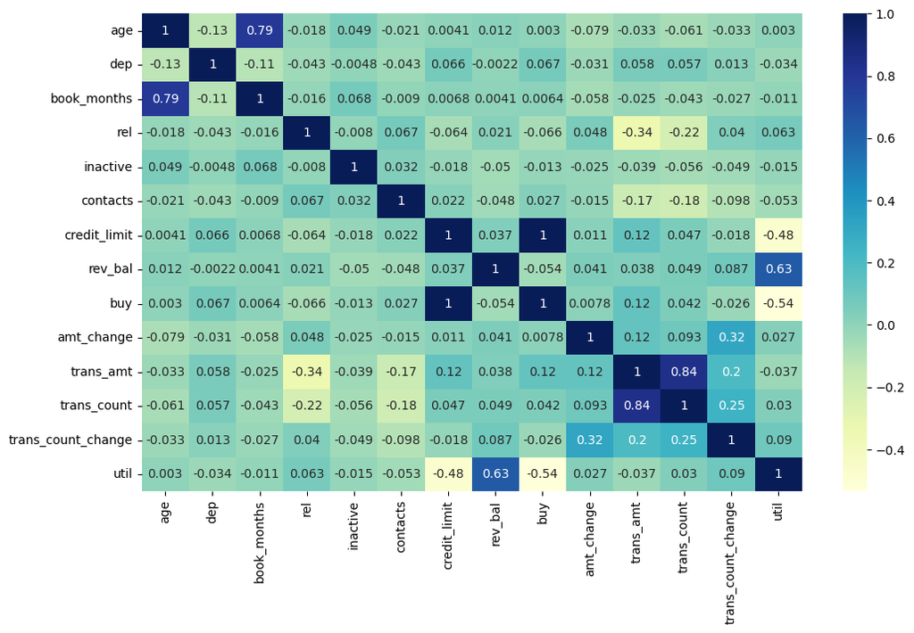

```python
plt.figure(figsize = (12, 7))
sns.heatmap(df[numcols].corr(), cmap = 'YlGnBu', annot = True)
plt.show()
```